# Final Project - Wood Thrush Response

Authors

Affiliation

Leona Myers

Colorado State University

Andie Hall

Colorado State University

# Climate Change and Avian Response: Assessing the Effects of CO₂ and Temperature on Wood Thrush Populations

## Abstract -

As climate change continues to drive research goals, different areas of impact arise surrounding not only humans but environmental and wildlife harm. Carbon dioxide is one of the main contributors to climate change, directly impacting annual temperatures and disturbing typical weather patterns. Wildlife, specifically avian species, are queue dependent on temperatures for specific phenological stages like migration (Lang et al. (2024)). In recent decades, there has been an observed decline to several avian populations, leading both avian and climate scientists to answer if climate change has disturbed the migration periods, which can directly impact the effectiveness of their breeding cycles. By analyzing annual temperatures and carbon emissions, this study aims to identify a correlation between changing variables and observed migration dates.

## Part 1. Introduction -

**Problem Overview**: In recent decades, global climate change, driven by increased carbon dioxide emissions, has contributed to rising temperatures and disrupted ecological systems (NOAA National Centers for Environmental Information (2024)). Many migratory bird species, such as the subject of this study, the Wood Thrush (Hylocichla mustelina), are particularly vulnerable to these changes due to their reliance on specific environmental cues for migration, breeding, and survival. The Wood Thrush is included on the Yellow Watch List for birds most at risk of extinction, and it is one of the most prominent examples of declining forest songbirds in North America (Ornithology (2024)). Populations have declined by 1.3% per year, resulting in a cumulative decline of approximately 50% between 1966 and 2019 (Ornithology (2024)). Declines in Wood Thrush populations have been observed across North America, yet the extent to which atmospheric CO2 levels and associated temperature changes contribute to these declines remains unclear.

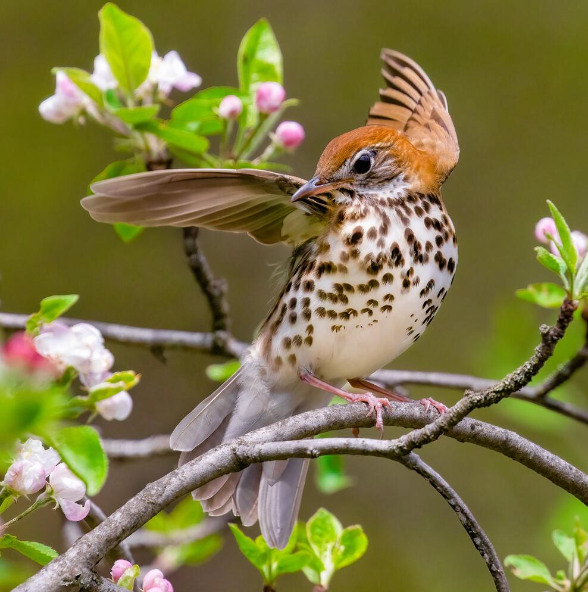

Figure 1: Wood Thrush - Lance Leonhardt (Audubon Vermont)

```r
knitr::include_graphics("~/Github/ESS-330-Final-Project-REDO/images/Wood_Thrush_Photo.jpg")
```

Source: Article Notebook

## Part 2. Materials and Methods -

### I. Research Goal and Data Sources

**This research will investigate the effects of atmospheric CO₂ concentrations and temperature changes on the population dynamics of the Wood Thrush (Hylocichla mustelina)**, a migratory songbird of conservation concern. The study integrates climate and ecological data from multiple large-scale sources: temperature records from the National Weather Service, (NOAA National Centers for Environmental Information (2024)) bird abundance and distribution data from Cornell’s eBird Dataset (Ornithology (2024)), and atmospheric CO₂ data from the Global Carbon Budget (Friedlingstein et al. (2023)). Using these data sources, we can create a model to help determine the effect of these variables on the arrival and departure dates of these species along the mid-northeastern coast of the United States from 1966 to 2019.

### II. Methods Overview

1. **Data acquisition**
   - Climate Data: National Weather Service
   - CO₂ Data: Global Carbon Budget
   - Bird Observation Data: Cornell Lab’s eBird dataset
2. **Data Cleaning and Processing**
   - **Climate Data -** Imported 7 different datasets from the states above that recorded annual temperatures for each month between 1966 and 2019 and combined into one large dataset, “All_Weather_Data.csv”
     - **Difficulties**: The data was extremely time-consuming to clean and process into a large dataset due to the website’s pdf format for data exports. Using Excel’s data from the file helped to import the data and allowed for processing and cleaning of the data before being inserted into the rProject data directory.
   - **CO2 Data -** Downloaded from the Global Carbon Budget and then uploaded to Rstudio. No additional cleaning was needed.
     - **Difficulties**: This data set only includes annual emission while other data sets include monthly data, but was the most accessible to our report.
   - **Wood Thrush Data -** Filtered Wood Thrush eBird data to between the years of 1966 and 2019, along with filtering the location of the bird to these specific states: Pennsylvania, West Virginia, Virginia, Kentucky, Ohio, Indiana, and Tennessee. “Wood_Thrush_Raw.csv”
     - **Difficulties**: The dataset is about 131.5 MB and cannot be uploaded to the git repository, meaning data sharing had to be done via email rather than sharing the actual repo for us to pull and push.
3. **Statistical Analysis**

   **Preliminary Analysis - Linear Regression Model**
   - To get a basic understand of the correlation relationship between temperature, CO2, and dates of observation, we created a linear model to visualize and create statistical information.

## Part 3. Preliminary Analysis - Exploring the Data

```r
# Library Codes used
library(tidyverse)
```

```r
library(tidymodels)
```

```r
library(here)
```

```r
library(readr)
library(lubridate)
library(zoo)
```

### I. Reading in Data Bases

```r
# CO2 Emissions
Annua_CO2_Emissions <- read_csv("data/annual-co2-emissions-per-country.csv")
```

```r
# Temperature Data
AllWeatherData <- read_csv("data/AllWeatherData.csv")
```

```r
# Wood Thrush Data
Wood_Thrush <- read_csv("data/Wood_Thrush.csv")
```

### II. Prepping/Cleaning Data Sets

```r
# Formatting Wood Thrush
Wood_Thrush <- Wood_Thrush |>
  select(COUNTRY, `COUNTRY CODE`, STATE, `OBSERVATION COUNT`, `OBSERVATION DATE`, LATITUDE, LONGITUDE) |>
  mutate(`OBSERVATION DATE` = as.Date(`OBSERVATION DATE`, format = "%m/%d/%Y"),
         Year = year(`OBSERVATION DATE`))

# Formatting Weather
Annual_Weather <- AllWeatherData |>
  select(Year, Annual, STATE)

# Formatting CO2
Annua_CO2_Emissions <- Annua_CO2_Emissions |>
  select(Year, `Annual CO₂ emissions`)

# Joined Data
Main_Data <- Wood_Thrush |>
  inner_join(Annual_Weather, by = c("Year", "STATE")) |>
  inner_join(Annua_CO2_Emissions, by = "Year") |>
  mutate(DayOfYear = yday(`OBSERVATION DATE`)) |>
  drop_na(Annual, `Annual CO₂ emissions`, DayOfYear)

# Creating Springtime Dataset
Spring_Arrival <- Main_Data |>
  group_by(year(`OBSERVATION DATE`)) |>
  slice_min(`OBSERVATION DATE`, with_ties = FALSE)

# Creating Falltime Dataset
Fall_Departure <- Main_Data |>
  group_by(year(`OBSERVATION DATE`)) |>
  slice_max(`OBSERVATION DATE`, with_ties = FALSE)
```

### III. Creating Linear Model for Observation Dates

#### Temperature Models -

```r
# Temperature Model - Spring
Temp_S_Main_Model <- lm(formula = DayOfYear ~ Annual, data = Spring_Arrival)

summary(Temp_S_Main_Model)
```

```
Call:
lm(formula = DayOfYear ~ Annual, data = Spring_Arrival)

Residuals:
    Min      1Q  Median      3Q     Max
-86.777  -1.755   5.228   9.191  21.902

Coefficients:
            Estimate Std. Error t value Pr(>|t|)
(Intercept)  35.7705    36.6956   0.975    0.334
Annual        0.9964     0.6456   1.543    0.129

Residual standard error: 20.59 on 52 degrees of freedom
Multiple R-squared:  0.0438,    Adjusted R-squared:  0.02541
F-statistic: 2.382 on 1 and 52 DF,  p-value: 0.1288
```

```r
springp1 <- ggplot(Spring_Arrival, aes(x = Annual, y = DayOfYear)) +
  geom_point(color = "#87CEFA", alpha = 0.6) +
  geom_smooth(method = "lm", color = "#9BCD9B", se = TRUE) +
  labs(
    title = "Effect of Annual Temperature on\nSpring Arrival Date",
    x = "Annual Average Temperature (°C)",
    y = "Day of Year of Spring Arrival"
  ) +
  theme_minimal()

# Temperature Model - Spring
Temp_F_Main_Model <- lm(formula = DayOfYear ~ Annual, data = Fall_Departure)

summary(Temp_F_Main_Model)
```

```
Call:
lm(formula = DayOfYear ~ Annual, data = Fall_Departure)

Residuals:
    Min      1Q  Median      3Q     Max
-34.127 -18.496  -7.249   9.039  57.588

Coefficients:
            Estimate Std. Error t value Pr(>|t|)
(Intercept) 392.1490    47.0361   8.337 3.75e-11 ***
Annual       -1.5966     0.8621  -1.852   0.0697 .
---
Signif. codes:  0 '***' 0.001 '**' 0.01 '*' 0.05 '.' 0.1 ' ' 1

Residual standard error: 24.59 on 52 degrees of freedom
Multiple R-squared:  0.06188,   Adjusted R-squared:  0.04384
F-statistic:  3.43 on 1 and 52 DF,  p-value: 0.06971
```

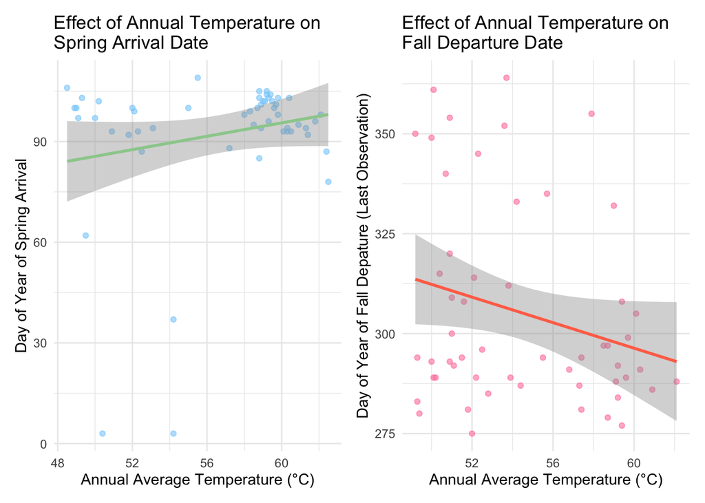

```r
fallp1 <- ggplot(Fall_Departure, aes(x = Annual, y = DayOfYear)) +
  geom_point(color = "palevioletred1", alpha = 0.6) +
  geom_smooth(method = "lm", color = "#FF7256", se = TRUE) +
  labs(
    title = "Effect of Annual Temperature on\nFall Departure Date",
    x = "Annual Average Temperature (°C)",
    y = "Day of Year of Fall Depature (Last Observation)"
  ) +
  theme_minimal()

# Combine plots side by side

library(patchwork)

combined_plot <- springp1 + fallp1

print(combined_plot)
```

#### CO2 Models -

```r
library(patchwork)
# CO2 Model - Spring
CO2_S_Main_Model <- lm(formula = DayOfYear ~ `Annual CO₂ emissions`, data = Spring_Arrival)

summary(CO2_S_Main_Model)
```

```
Call:
lm(formula = DayOfYear ~ `Annual CO₂ emissions`, data = Spring_Arrival)

Residuals:
    Min      1Q  Median      3Q     Max
-90.777   1.588   4.938   9.630  13.831

Coefficients:
                         Estimate Std. Error t value Pr(>|t|)
(Intercept)             1.023e+02  2.019e+01   5.066 5.46e-06 ***
`Annual CO₂ emissions` -1.660e-09  3.302e-09  -0.503    0.617
---
Signif. codes:  0 '***' 0.001 '**' 0.01 '*' 0.05 '.' 0.1 ' ' 1

Residual standard error: 21.01 on 52 degrees of freedom
Multiple R-squared:  0.004839,  Adjusted R-squared:  -0.0143
F-statistic: 0.2529 on 1 and 52 DF,  p-value: 0.6172
```

```r
springp2 <- ggplot(Spring_Arrival, aes(x = `Annual CO₂ emissions`, y = DayOfYear)) +
  geom_point(color = "#FFBBFF", alpha = 0.6) +
  geom_smooth(method = "lm", color = "palevioletred2", se = TRUE) +
  labs(
    title = "Effect of Annual CO2 Emissions on\npring Arrival Date",
    x = "Annual CO2 Emissions (ppm)",
    y = "Day of Year of Spring Arrival"
  ) +
  theme_minimal()

# CO2 Model - Fall
CO2_F_Main_Model <- lm(formula = DayOfYear ~ `Annual CO₂ emissions`, data = Fall_Departure)

summary(CO2_F_Main_Model)
```

```
Call:
lm(formula = DayOfYear ~ `Annual CO₂ emissions`, data = Fall_Departure)

Residuals:
   Min     1Q Median     3Q    Max
-27.19 -17.02 -12.16  10.40  63.22

Coefficients:
                        Estimate Std. Error t value Pr(>|t|)
(Intercept)            2.912e+02  2.432e+01  11.974   <2e-16 ***
`Annual CO₂ emissions` 2.323e-09  3.977e-09   0.584    0.562
---
Signif. codes:  0 '***' 0.001 '**' 0.01 '*' 0.05 '.' 0.1 ' ' 1

Residual standard error: 25.3 on 52 degrees of freedom
Multiple R-squared:  0.006521,  Adjusted R-squared:  -0.01258
F-statistic: 0.3413 on 1 and 52 DF,  p-value: 0.5616
```

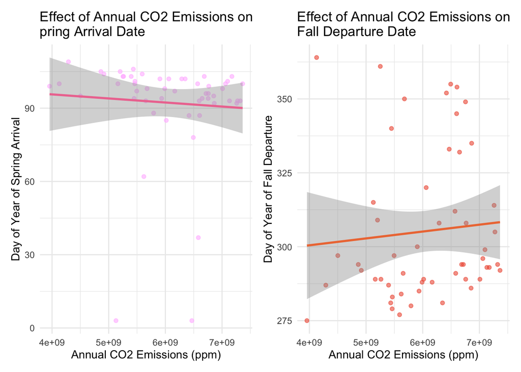

```r
fallp2 <- ggplot(Fall_Departure, aes(x = `Annual CO₂ emissions`, y = DayOfYear)) +
  geom_point(color = "tomato2", alpha = 0.6) +  # Scatter points
  geom_smooth(method = "lm", color = "#EE7942", se = TRUE) +  # Regression line with confidence interval
  labs(
    title = "Effect of Annual CO2 Emissions on\nFall Departure Date",
    x = "Annual CO2 Emissions (ppm)",  # Adjust units if needed
    y = "Day of Year of Fall Departure"
  ) +
  theme_minimal()

combined_plot2 <- springp2 + fallp2

print(combined_plot2)
```

## Part 4. Main Analysis - Machine Learning Model

### I. Splitting and CV folds

```r
set.seed(123)
WT_split <- initial_split(Main_Data, prop = 0.8)
WT_train <- training(WT_split)
WT_test  <- testing(WT_split)
WT_cv <- vfold_cv(WT_train, v = 5)
```

### II. Recipes

```r
# CO2 Recipe
CO2_rec <- recipe(formula = DayOfYear ~ `Annual CO₂ emissions`, data = WT_train) |>
  step_log(all_predictors()) |>
  step_naomit(all_predictors(), all_outcomes())

# Temperature Recipe
Temp_rec <- recipe(formula = DayOfYear ~ Annual, data = WT_train) |>
  step_log(all_predictors(), offset = 1) |>
  step_naomit(all_predictors(), all_outcomes())
```

### III. Define Models

```r
lm_model <- linear_reg() |> set_engine("lm") |> set_mode("regression")
rf_model <- rand_forest(trees = 100) |> set_engine("ranger") |> set_mode("regression")
xg_model <- boost_tree() |> set_engine("xgboost") |> set_mode("regression")
```

### IV. Workflows

```r
# CO2 Workflows
wf_lm_CO2 <- workflow() |>
  add_model(lm_model) |>
  add_recipe(CO2_rec)

wf_rf_CO2 <- workflow() |>
  add_model(rf_model) |>
  add_recipe(CO2_rec)

wf_xg_CO2 <- workflow() |>
  add_model(xg_model) |>
  add_recipe(CO2_rec)

# Temperature Workflows
wf_lm_Temp <- workflow() |>
  add_model(lm_model) |>
  add_recipe(Temp_rec)

wf_rf_Temp <- workflow() |>
  add_model(rf_model) |>
  add_recipe(Temp_rec)

wf_xg_Temp <- workflow() |>
  add_model(xg_model) |>
  add_recipe(Temp_rec)
```

### V.a CO2 - Fitting Models

```r
# Linear - CO2
res_lm_CO2 <- fit_resamples(
  wf_lm_CO2,
  resamples = WT_cv,
  metrics = metric_set(rmse, rsq),
  control = control_resamples(save_pred = TRUE)
)

# Random Forest - CO2
res_rf_CO2 <- fit_resamples(
  wf_rf_CO2,
  resamples = WT_cv,
  metrics = metric_set(rmse, rsq),
  control = control_resamples(save_pred = TRUE)
)

# XG Boosted Tree - CO2
res_xg_CO2 <- fit_resamples(
  wf_xg_CO2,
  resamples = WT_cv,
  metrics = metric_set(rmse, rsq),
  control = control_resamples(save_pred = TRUE)
)
```

### V.b Temperature - Fitting Models

```r
# Linear - Temperature
res_lm_Temp <- fit_resamples(
  wf_lm_Temp,
  resamples = WT_cv,
  metrics = metric_set(rmse, rsq),
  control = control_resamples(save_pred = TRUE)
)

# Random Forest - Temperature
res_rf_Temp <- fit_resamples(
  wf_rf_Temp,
  resamples = WT_cv,
  metrics = metric_set(rmse, rsq),
  control = control_resamples(save_pred = TRUE)
)

# XG Boosted Tree - Temperature
res_xg_Temp <- fit_resamples(
  wf_xg_Temp,
  resamples = WT_cv,
  metrics = metric_set(rmse, rsq),
  control = control_resamples(save_pred = TRUE)
)
```

### VI. Metrics and Comparison

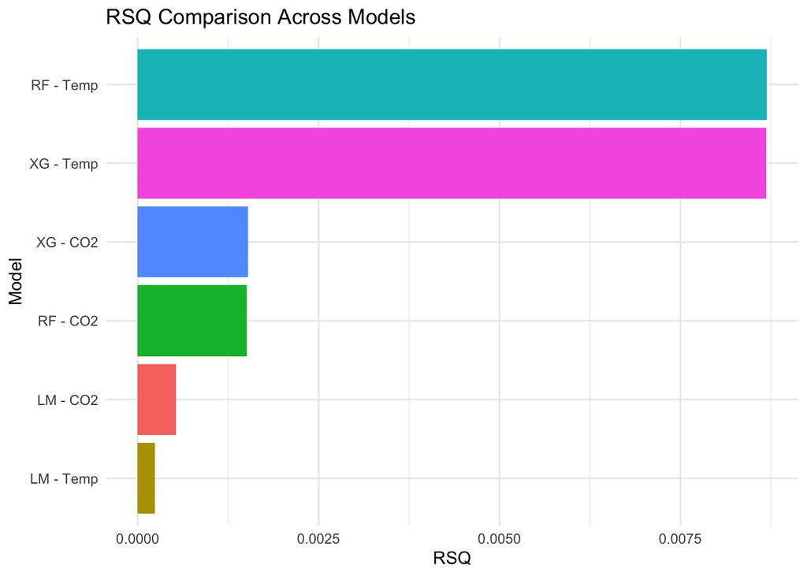

```r
all_results <- bind_rows(
  collect_metrics(res_lm_CO2) |> mutate(Model = "LM - CO2"),
  collect_metrics(res_rf_CO2) |> mutate(Model = "RF - CO2"),
  collect_metrics(res_xg_CO2) |> mutate(Model = "XG - CO2"),
  collect_metrics(res_lm_Temp) |> mutate(Model = "LM - Temp"),
  collect_metrics(res_rf_Temp) |> mutate(Model = "RF - Temp"),
  collect_metrics(res_xg_Temp) |> mutate(Model = "XG - Temp")
)

all_results |>
  filter(.metric == "rsq") |>
  ggplot(aes(x = reorder(Model, mean), y = mean, fill = Model)) +
  geom_col(show.legend = FALSE) +
  labs(
    title = "RSQ Comparison Across Models",
    x = "Model",
    y = "RSQ"
  ) +
  coord_flip() +
  theme_minimal()
```

## Part 5. Full Analysis - Spring Arrival and Fall Departure Random Forest Predictions

### I. Fit to Full Model (Spring and Fall | CO2 and Temperature)

```r
# Temperature Models
rf_temp_spring_fit <- fit(wf_rf_Temp, data = Spring_Arrival)

rf_temp_fall_fit <- fit(wf_rf_Temp, data = Fall_Departure)

# CO2 Models
rf_CO2_spring_fit <- fit(wf_rf_CO2, data = Spring_Arrival)

rf_CO2_fall_fit <- fit(wf_rf_CO2, data = Fall_Departure)
```

### II. Predictions for Models

```r
# Temperature Models
temp_spring_preds <- predict(rf_temp_spring_fit, Spring_Arrival) |>
  bind_cols(Spring_Arrival)

temp_fall_preds <- predict(rf_temp_fall_fit, Fall_Departure) |>
  bind_cols(Fall_Departure)

# CO2 Models
CO2_spring_preds <- predict(rf_CO2_spring_fit, Spring_Arrival) |>
  bind_cols(Spring_Arrival)

CO2_fall_preds <- predict(rf_CO2_fall_fit, Fall_Departure) |>
  bind_cols(Fall_Departure)
```

### III. Plotting Temperature Prediction Models

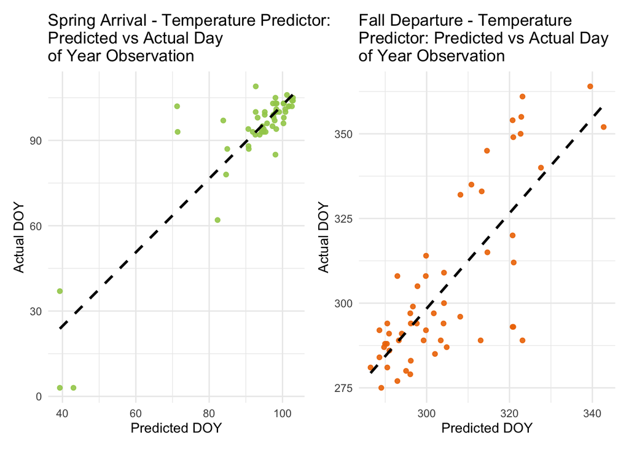

```r
library(patchwork)

# Spring Arrival
p1 <- ggplot(temp_spring_preds, aes(x = .pred, y = DayOfYear)) +
  geom_point(alpha = 0.9, color = "#A2CD5A") +
  geom_smooth(method = "lm", se = FALSE, color = "black", linetype = "dashed") +
  theme_minimal() +
  labs(title = "Spring Arrival - Temperature Predictor:\nPredicted vs Actual Day\nof Year Observation",
       x = "Predicted DOY", y = "Actual DOY")

# Fall Departure
p2 <- ggplot(temp_fall_preds, aes(x = .pred, y = DayOfYear)) +
  geom_point(alpha = 0.9, color = "darkorange2") +
  geom_smooth(method = "lm", se = FALSE, color = "black", linetype = "dashed") +
  theme_minimal() +
  labs(title = "Fall Departure - Temperature\nPredictor: Predicted vs Actual Day\nof Year Observation",
       x = "Predicted DOY", y = "Actual DOY")


p1 + p2
```

### IV. Plotting CO2 Prediction Models

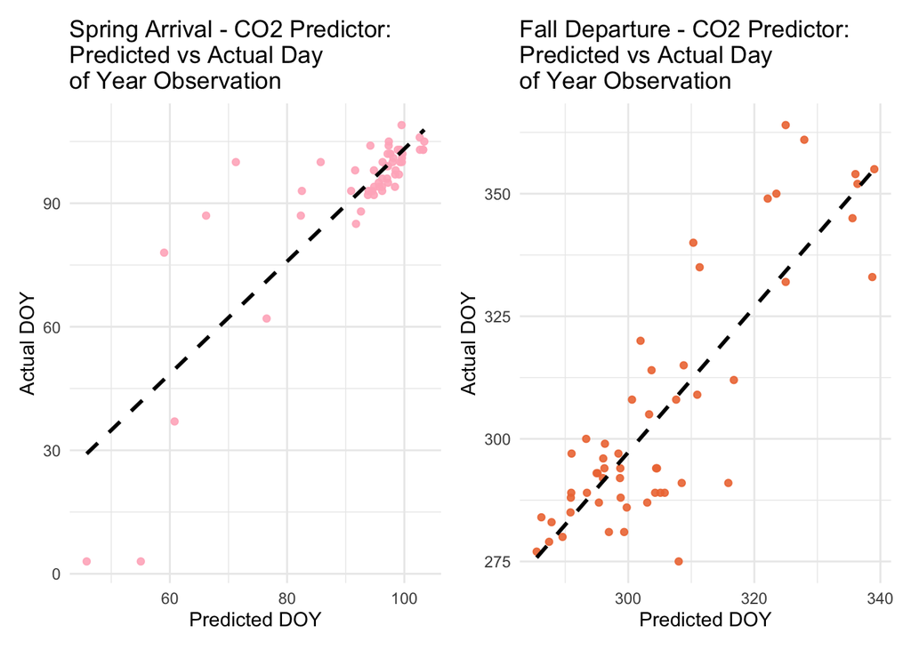

```r
# Spring Arrival
p3 <- ggplot(CO2_spring_preds, aes(x = .pred, y = DayOfYear)) +
  geom_point(alpha = 0.9, color = "pink1") +
  geom_smooth(method = "lm", se = FALSE, color = "black", linetype = "dashed") +
  theme_minimal() +
  labs(title = "Spring Arrival - CO2 Predictor:\nPredicted vs Actual Day\nof Year Observation",
       x = "Predicted DOY", y = "Actual DOY")

# Fall Departure
p4 <- ggplot(CO2_fall_preds, aes(x = .pred, y = DayOfYear)) +
  geom_point(alpha = 0.9, color = "sienna2") +
  geom_smooth(method = "lm", se = FALSE, color = "black", linetype = "dashed") +
  theme_minimal() +
  labs(title = "Fall Departure - CO2 Predictor:\nPredicted vs Actual Day\nof Year Observation",
       x = "Predicted DOY", y = "Actual DOY")


p3 + p4
```

## **Part 6. Results Discussion**

To assess the relationship between climate variables and Wood Thrush migration phenology, we implemented and evaluated six machine learning models: linear regression, random forest, and XGBoost—each applied separately to CO₂ and temperature predictor datasets. Performance was measured using 5-fold cross-validation due to the size of the datasets and runtime constraints. With this we had 4 total final datasets, separated by Spring/Fall and Temperature/CO₂.

### **I. Spring Arrival Predictions**

#### CO₂ Models -

CO₂’s Spring model had similar results, with a clustering of points in the top right hand corner and fairly close to the actual dates. This is sensible with how CO₂ comes as a direct impact onto temperature and can provide data that states that as they move in similar directions, they both have impacts on migration periods and dates.

### III. Overall Analysis Conclusion

**Future studies** could include more sophisticated models on computers that can run more in-depth and larger datasets. Along with more skill knowledge of RStudio and how to better create models that both predict and demonstrate correlation between predictor and response variables.

**Some limitations** that we encountered throughout this project was mostly through data analysis and cleaning. Our climate data was particular to how it was supposed to be cleaned and took many hours of excel refining to be usable in RStudio. Another major roadblock that we encountered and was a large portion of our challenges was the rendering of our files to be able to display them as a website through Github pages. With multiple meetings dedicated to resolving this issue, we still faced many errors with long rendering periods, models taking hours to process, and seemingly endless errors. However, we preserved through it all to create a simple yet replicable method to help understand the correlation between temperature, CO₂, and migration dates.

**The significance of this study** relates back to our original problem that inspired our target. Avian species are one of the longest standing species groups, dating back to before records existed. With their adaptable and resilient nature, they are ideal for studies regarding changes to key factors that can drastically harm their populations. Our goal with this study was to begin a coding process that can be replicated and used across multiple species of different conservation statuses. While this report may need more refining and different methods to achieve a successful and accurate depiction of the impact on these variables, it begins the discussion of how humans are not the only species to be impacted by CO₂ emissions and temperature variance.

**Our take away** from this is that even as junior data analysts, we can create studies that can be built upon and developed to create solutions or incentives for policy management of wildlife and emissions. We hoped to contribute to the wider ecological research surrounding conservation of native and important species.

### **IV. Visual Summary**

We generated the following visualizations to illustrate key trends:

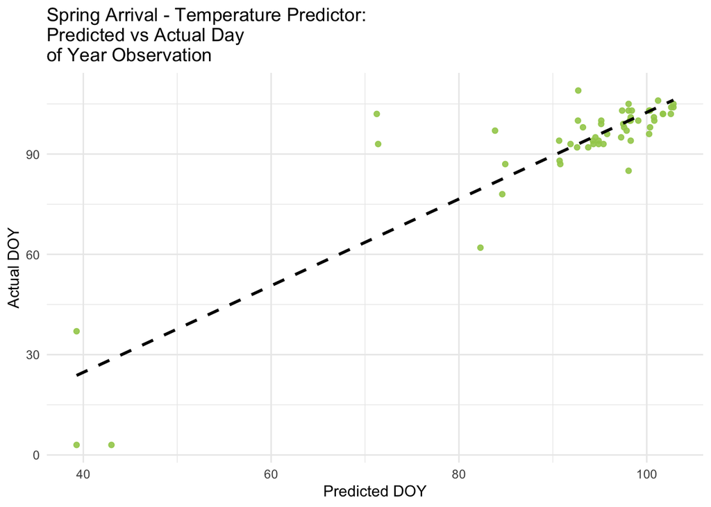

```r
print(p1)
```

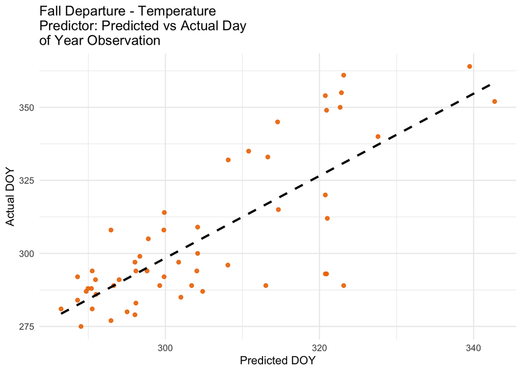

```r
print(p2)
```

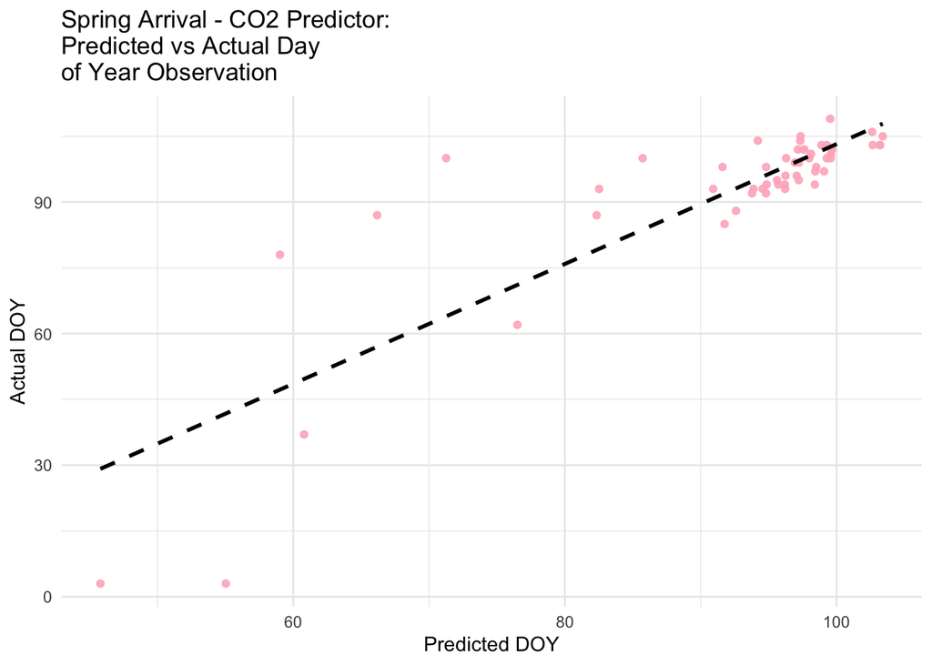

```r
print(p3)
```

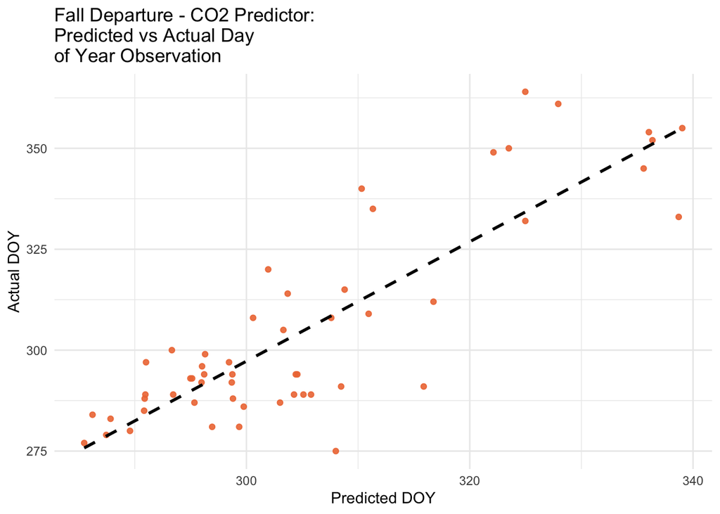

```r
print(p4)
```

## References

Friedlingstein, P. et al. (2023). Global carbon budget 2023. *Earth System Science Data*, *15*, 123–145. https://doi.org/10.5194/essd-15-123-2023

Lang, W. et al. (2024). Phenological divergence between plants and animals under climate change. *Nature Ecology and Evolution*, *9*, 261–272. https://doi.org/https://doi.org/10.1038/s41559-024-02597-0

NOAA National Centers for Environmental Information. (2024). *Monthly global climate report for annual 2023*. https://www.ncei.noaa.gov/access/monitoring/monthly-report/global/202313

Ornithology, C. L. of. (2024). *Wood thrush life history*. https://www.allaboutbirds.org/guide/Wood_Thrush/lifehistory